# Project: Investigate a Dataset (a TMDb Movie Dataset ) by Mohamed Atef

- Introduction
- Data Wrangling
- Exploratory Data Analysis
- Conclusions

## Introduction

> This data set contains information about 10,000 movies collected from The Movie Database (TMDb), including user ratings and revenue,cast,release year.

> Brief Description of each column in the dataset

> **1.id** - Unique id's for each row

> **2.imdb_id** - System generated unique id

> **3.popularity** - popularity score

> **4.budget** - budget in dollars

> **5.revenue** - revenue in dollars

> **6.original_title** - Movie title

> **7.cast** - cast performed in movie

> **8.homepage** - website link of movie

> **9.director** - director name

> **10.tagline** - tagline of movie

> **11.keywords** - words used to give significant idea

> **12.overview** - general review of movie

> **13.runtime** - movie duration in seconds

> **14.genres** - categories of movie

> **15.production_companies** - company name which manages a movie process from start to finish

> **16.release_date** - movie releasing date

> **17.vote_count** - votes given by viewers

> **18.vote_average** - average votes given by viewers

> **19.release_year** - movie releasing year

> **20.budget_adj**-budget in 2010 dollars,accounting for inflation

> **21.revenue_adj** -revenue in 2010 dollars,accounting for inflation

**Questions that I would like to use on exploring and investigating TMDB dataset.**

- **1.What kind of movie genres are made the most?**
- **2.Which genres are most popular from year to year?**
- **3.In which year most of the movies released?**
- **4.What kinds of properties are associated with movies that have high revenues.**
- **5. High Gross profit movies from year to year**
- **6. High Budget Movies from year to year.**
- **7.What are the months when most of the movies released?**
- **8.As per popularity score which actor / actress is most famous?**
- **9.As per popularity score which movie is most famous?**
- **10.As per Average vote score which movie is most famous?**
- **11.As per Average vote score which Actor/Actress is most famous?**
- **12.Movies which have earned highest revenue.**
- **13.Most Frequent Runtime of movies**
- **14.Most famous action directors**
- **15. Most famous Actors in Action genre.**
- **16.Which production companies have made most of the movies**
- **17.Most frequent Keywords used in every genres.**
- **18.Older or newer movies get more popularity score**

### This cell include the required imports of libraries to be used during the analysis phase

```python
import pandas as pd
import numpy as np
%matplotlib inline
from matplotlib import pyplot as plt
import seaborn as sns
```

## Data Wrangling

```python
#Read TMDb movie csv file
tmdb_movies = pd.read_csv('tmdb-movies-new.csv')
tmdb_movies.head()
```

|  | id | imdb_id | popularity | budget | revenue | original_title | cast | homepage | director | tagline | ... | overview | runtime | genres | production_companies | release_date | vote_count | vote_average | release_year | budget_adj | revenue_adj |
| --- | --- | --- | --- | --- | --- | --- | --- | --- | --- | --- | --- | --- | --- | --- | --- | --- | --- | --- | --- | --- | --- |
| 0 | 135397 | tt0369610 | 32.985763 | 150000000 | 1513528810 | Jurassic World | Chris Pratt\|Bryce Dallas Howard\|Irrfan Khan\|Vi... | http://www.jurassicworld.com/ | Colin Trevorrow | The park is open. | ... | Twenty-two years after the events of Jurassic ... | 124 | Action\|Adventure\|Science Fiction\|Thriller | Universal Studios\|Amblin Entertainment\|Legenda... | 6/9/15 | 5562 | 6.5 | 2015 | 1.379999e+08 | 1.392446e+09 |
| 1 | 76341 | tt1392190 | 28.419936 | 150000000 | 378436354 | Mad Max: Fury Road | Tom Hardy\|Charlize Theron\|Hugh Keays-Byrne\|Nic... | http://www.madmaxmovie.com/ | George Miller | What a Lovely Day. | ... | An apocalyptic story set in the furthest reach... | 120 | Action\|Adventure\|Science Fiction\|Thriller | Village Roadshow Pictures\|Kennedy Miller Produ... | 5/13/15 | 6185 | 7.1 | 2015 | 1.379999e+08 | 3.481613e+08 |
| 2 | 262500 | tt2908446 | 13.112507 | 110000000 | 295238201 | Insurgent | Shailene Woodley\|Theo James\|Kate Winslet\|Ansel... | http://www.thedivergentseries.movie/#insurgent | Robert Schwentke | One Choice Can Destroy You | ... | Beatrice Prior must confront her inner demons ... | 119 | Adventure\|Science Fiction\|Thriller | Summit Entertainment\|Mandeville Films\|Red Wago... | 3/18/15 | 2480 | 6.3 | 2015 | 1.012000e+08 | 2.716190e+08 |
| 3 | 140607 | tt2488496 | 11.173104 | 200000000 | 2068178225 | Star Wars: The Force Awakens | Harrison Ford\|Mark Hamill\|Carrie Fisher\|Adam D... | http://www.starwars.com/films/star-wars-episod... | J.J. Abrams | Every generation has a story. | ... | Thirty years after defeating the Galactic Empi... | 136 | Action\|Adventure\|Science Fiction\|Fantasy | Lucasfilm\|Truenorth Productions\|Bad Robot | 12/15/15 | 5292 | 7.5 | 2015 | 1.839999e+08 | 1.902723e+09 |
| 4 | 168259 | tt2820852 | 9.335014 | 190000000 | 1506249360 | Furious 7 | Vin Diesel\|Paul Walker\|Jason Statham\|Michelle ... | http://www.furious7.com/ | James Wan | Vengeance Hits Home | ... | Deckard Shaw seeks revenge against Dominic Tor... | 137 | Action\|Crime\|Thriller | Universal Pictures\|Original Film\|Media Rights ... | 4/1/15 | 2947 | 7.3 | 2015 | 1.747999e+08 | 1.385749e+09 |

5 rows × 21 columns

```python
tmdb_movies.shape
```

```
(10866, 21)
```

### Let's get intuition of our data by checking its types,null values,duplicates.

```python
tmdb_movies.dtypes
```

```
id                        int64
imdb_id                  object
popularity              float64
budget                    int64
revenue                   int64
original_title           object
cast                     object
homepage                 object
director                 object
tagline                  object
keywords                 object
overview                 object
runtime                   int64
genres                   object
production_companies     object
release_date             object
vote_count                int64
vote_average            float64
release_year              int64
budget_adj              float64
revenue_adj             float64
dtype: object
```

### We have to convert release_date column to datetime format as it is in object type.

```python
tmdb_movies['release_date'] = pd.to_datetime(tmdb_movies['release_date'])
```

### Assure if changes had been done as we wanted.

```python
tmdb_movies.dtypes
```

```
id                               int64
imdb_id                         object
popularity                     float64
budget                           int64
revenue                          int64
original_title                  object
cast                            object
homepage                        object
director                        object
tagline                         object
keywords                        object
overview                        object
runtime                          int64
genres                          object
production_companies            object
release_date            datetime64[ns]
vote_count                       int64
vote_average                   float64
release_year                     int64
budget_adj                     float64
revenue_adj                    float64
dtype: object
```

### Let's get [release month] & [weekday] from [release_date] column

```python
tmdb_movies['release_month'] = tmdb_movies['release_date'].dt.month
tmdb_movies['release_day'] = tmdb_movies['release_date'].dt.strftime("%A")
```

### Let's return a description of updated dataset

```python
tmdb_movies.describe()
```

|  | id | popularity | budget | revenue | runtime | vote_count | vote_average | release_year | budget_adj | revenue_adj | release_month |
| --- | --- | --- | --- | --- | --- | --- | --- | --- | --- | --- | --- |
| count | 10866.000000 | 10866.000000 | 1.086600e+04 | 1.086600e+04 | 10866.000000 | 10866.000000 | 10866.000000 | 10866.000000 | 1.086600e+04 | 1.086600e+04 | 10866.000000 |
| mean | 66064.177434 | 0.646441 | 1.462570e+07 | 3.982332e+07 | 102.070863 | 217.389748 | 5.974922 | 2001.322658 | 1.755104e+07 | 5.136436e+07 | 6.827259 |
| std | 92130.136561 | 1.000185 | 3.091321e+07 | 1.170035e+08 | 31.381405 | 575.619058 | 0.935142 | 12.812941 | 3.430616e+07 | 1.446325e+08 | 3.441802 |
| min | 5.000000 | 0.000065 | 0.000000e+00 | 0.000000e+00 | 0.000000 | 10.000000 | 1.500000 | 1960.000000 | 0.000000e+00 | 0.000000e+00 | 1.000000 |
| 25% | 10596.250000 | 0.207583 | 0.000000e+00 | 0.000000e+00 | 90.000000 | 17.000000 | 5.400000 | 1995.000000 | 0.000000e+00 | 0.000000e+00 | 4.000000 |
| 50% | 20669.000000 | 0.383856 | 0.000000e+00 | 0.000000e+00 | 99.000000 | 38.000000 | 6.000000 | 2006.000000 | 0.000000e+00 | 0.000000e+00 | 7.000000 |
| 75% | 75610.000000 | 0.713817 | 1.500000e+07 | 2.400000e+07 | 111.000000 | 145.750000 | 6.600000 | 2011.000000 | 2.085325e+07 | 3.369710e+07 | 10.000000 |
| max | 417859.000000 | 32.985763 | 4.250000e+08 | 2.781506e+09 | 900.000000 | 9767.000000 | 9.200000 | 2015.000000 | 4.250000e+08 | 2.827124e+09 | 12.000000 |

## Data Cleaning

### Check shape of dataframe

```python
tmdb_movies.shape
```

```
(10866, 23)
```

## Dropping Columns:

#### Month, weekday are gathered from release_date column, which means release_date column is not required anymore as it doesn't include important data.

#### imdb_id column contains some system generated numbers which are not included in our needs.

#### Similarly homepage data is also not very useful for us.

```python
tmdb_movies.drop(labels = ['imdb_id','homepage','release_date'],axis =1,inplace =True)
```

### Check shap of dataframe after removing last columns

```python
tmdb_movies.shape
```

```
(10866, 20)
```

### Let's check if our data contains some duplicates & nan values

```python
sum(tmdb_movies.duplicated())
```

```
1
```

### Let's drop dublicates

```python
tmdb_movies.drop_duplicates(keep= 'first',inplace = True)
```

### Let's check shape of dataframe after removing dublicates

```python
tmdb_movies.shape
```

```
(10865, 20)
```

#### Let's display null values in all of the dataframe

```python
total = tmdb_movies.isnull().sum().sort_values(ascending = False)
percent = ((tmdb_movies.isnull().sum() / tmdb_movies.shape[0])*100).sort_values(ascending = False)
pd.concat([total,percent],axis = 1,keys = ['total','percent'])
```

|  | total | percent |
| --- | --- | --- |
| tagline | 2824 | 25.991717 |
| keywords | 1493 | 13.741371 |
| production_companies | 1030 | 9.479982 |
| cast | 76 | 0.699494 |
| director | 44 | 0.404970 |
| genres | 23 | 0.211689 |
| overview | 4 | 0.036815 |
| popularity | 0 | 0.000000 |
| budget | 0 | 0.000000 |
| revenue | 0 | 0.000000 |
| original_title | 0 | 0.000000 |
| release_day | 0 | 0.000000 |
| release_month | 0 | 0.000000 |
| runtime | 0 | 0.000000 |
| vote_count | 0 | 0.000000 |
| vote_average | 0 | 0.000000 |
| release_year | 0 | 0.000000 |
| budget_adj | 0 | 0.000000 |
| revenue_adj | 0 | 0.000000 |
| id | 0 | 0.000000 |

#### check null values

```python
tmdb_movies.isnull().sum()
```

```
id                         0
popularity                 0
budget                     0
revenue                    0
original_title             0
cast                      76
director                  44
tagline                 2824
keywords                1493
overview                   4
runtime                    0
genres                    23
production_companies    1030
vote_count                 0
vote_average               0
release_year               0
budget_adj                 0
revenue_adj                0
release_month              0
release_day                0
dtype: int64
```

### Let's drop null values from dataframe.

```python
tmdb_movies.dropna(how = 'any',inplace = True)
```

### check shape of dataframe after dropping null values

```python
tmdb_movies.shape
```

```
(7031, 20)
```

### Checking if our dataset contains runtime of zero or less than zero

```python
is_runtime_zero = tmdb_movies['runtime'] == 0
tmdb_movies[is_runtime_zero].shape , tmdb_movies[is_runtime_zero].index.values
```

```
((3, 20), array([ 334, 1289, 1293], dtype=int64))
```

```python
tmdb_movies[is_runtime_zero]
```

|  | id | popularity | budget | revenue | original_title | cast | director | tagline | keywords | overview | runtime | genres | production_companies | vote_count | vote_average | release_year | budget_adj | revenue_adj | release_month | release_day |
| --- | --- | --- | --- | --- | --- | --- | --- | --- | --- | --- | --- | --- | --- | --- | --- | --- | --- | --- | --- | --- |
| 334 | 361931 | 0.357654 | 0 | 0 | Ronaldo | Cristiano Ronaldo | Anthony Wonke | Astonishing. Intimate. Definitive. | biography\|soccer player | Filmed over 14 months with unprecedented acces... | 0 | Documentary | On The Corner Films\|We Came, We Saw, We Conque... | 80 | 6.5 | 2015 | 0.000000e+00 | 0.0 | 11 | Monday |
| 1289 | 286372 | 0.037459 | 3250000 | 0 | Treehouse | J. Michael Trautmann\|Dana Melanie\|Daniel Fredr... | Michael G. Bartlett | No kids allowed | kidnapping\|brutality\|violence\|teenager\|discovery | A teenage boy discovers the perpetrators of se... | 0 | Thriller\|Horror\|Mystery | Tiberius Film | 16 | 3.4 | 2014 | 2.993546e+06 | 0.0 | 10 | Monday |
| 1293 | 286256 | 0.036904 | 0 | 0 | Tim Maia | Robson Nunes\|Babú Santana\|Alinne Moraes\|Cauã... | Mauro Lima | Original language PORTUGUESE | brazilian\|biography\|music\|drama\|documentary | Biopic of Brazilian singer Tim Maia, from his ... | 0 | Documentary\|Drama\|Music | Globo Filmes | 14 | 6.0 | 2014 | 0.000000e+00 | 0.0 | 10 | Thursday |

### check shape of dataframe

```python
tmdb_movies.shape
```

```
(7031, 20)
```

### There are some fields separted by pipe '|' character. For better analysis, let's split them up.

```python
def separate(data):
    return data.str[0:].str.split('|',expand = True)
```

```python
genres = separate(tmdb_movies['genres'])
keywords = separate(tmdb_movies['keywords'])
cast = separate(tmdb_movies['cast'])
production_companies = separate(tmdb_movies['production_companies'])
```

### Splitting done successfully

### Let's show genres and cast heading

```python
cast.head()
```

|  | 0 | 1 | 2 | 3 | 4 |
| --- | --- | --- | --- | --- | --- |
| 0 | Chris Pratt | Bryce Dallas Howard | Irrfan Khan | Vincent D'Onofrio | Nick Robinson |
| 1 | Tom Hardy | Charlize Theron | Hugh Keays-Byrne | Nicholas Hoult | Josh Helman |
| 2 | Shailene Woodley | Theo James | Kate Winslet | Ansel Elgort | Miles Teller |
| 3 | Harrison Ford | Mark Hamill | Carrie Fisher | Adam Driver | Daisy Ridley |
| 4 | Vin Diesel | Paul Walker | Jason Statham | Michelle Rodriguez | Dwayne Johnson |

```python
genres.head()
```

|  | 0 | 1 | 2 | 3 | 4 |
| --- | --- | --- | --- | --- | --- |
| 0 | Action | Adventure | Science Fiction | Thriller | None |
| 1 | Action | Adventure | Science Fiction | Thriller | None |
| 2 | Adventure | Science Fiction | Thriller | None | None |
| 3 | Action | Adventure | Science Fiction | Fantasy | None |
| 4 | Action | Crime | Thriller | None | None |

### Now, I have to split the data by pipe character '|' & then melt it to one single column. Hence, I will get separate dataframes for each such column ('genres','cast','keywords','production_companies'). After that, I will be able to merge any of the two dataframes for answering question.

### To acheive the desired result, I have to copy the id column from tmdb_movies dataframe so that it would help me to merge other dataframes on 'id' column.

```python
genres['id'] = tmdb_movies['id']
cast['id'] = tmdb_movies['id']
keywords['id'] = tmdb_movies['id']
production_companies['id'] = tmdb_movies['id']
```

### Count null cells

```python
genres.isnull().sum() , cast.isnull().sum(),keywords.isnull().sum(), production_companies.isnull().sum()
```

```
(0        0
 1     1262
 2     3418
 3     5584
 4     6634
 id       0
 dtype: int64,
 0       0
 1      30
 2      45
 3      72
 4     158
 id      0
 dtype: int64,
 0        0
 1      462
 2     1016
 3     1708
 4     2426
 id       0
 dtype: int64,
 0        0
 1     2149
 2     4060
 3     5405
 4     6123
 id       0
 dtype: int64)
```

#### keep id column apply merge on rest of the columns

```python
def melt_df(data ):
    return pd.melt(data,col_level = 0,id_vars = 'id',value_vars = [0,1,2,3,4]) #keep id column apply merge on rest of the columns
```

#### apply merge and keep id Field/Column

```python
genres=melt_df(genres)
cast = melt_df(cast)
keywords = melt_df(keywords)
production_companies = melt_df(production_companies)
```

```python
genres.head()
```

|  | id | variable | value |
| --- | --- | --- | --- |
| 0 | 135397 | 0 | Action |
| 1 | 76341 | 0 | Action |
| 2 | 262500 | 0 | Adventure |
| 3 | 140607 | 0 | Action |
| 4 | 168259 | 0 | Action |

### According to results in genres dataset, the column named 'variable' is containing name of our columns before merging, which isnot required for our use. Now, I will drop 'variable' column.

```python
grouped_df = [genres,cast,keywords,production_companies]
for df in grouped_df:
    df.columns = ['id','variable','value']
    df.drop(df.columns[1],axis=1, inplace=True)
```

##### we have dropped column with index [1] in df, which refer to column named with : 'variable'

## Let's Rename column of DataFrames

```python
genres.rename(columns = {'value':'genres'},inplace = True)
cast.rename(columns = {'value':'cast'},inplace = True)
production_companies.rename(columns = {'value':'production_companies'},inplace = True)
keywords.rename(columns = {'value':'keywords'},inplace = True)
```

### Dropping all the null values

```python
genres.dropna(inplace = True)
cast.dropna(inplace = True)
keywords.dropna(inplace = True)
production_companies.dropna(inplace = True)
```

## We have been able to make different DataFrames for each of the below columns So it would be good idea to be dropped from our primary DataFrame

```python
movies=tmdb_movies.drop(columns = ['cast','keywords','production_companies', 'genres'],axis = 1)
```

### Let's test cast heading

```python
cast.head()
```

|  | id | cast |
| --- | --- | --- |
| 0 | 135397 | Chris Pratt |
| 1 | 76341 | Tom Hardy |
| 2 | 262500 | Shailene Woodley |
| 3 | 140607 | Harrison Ford |
| 4 | 168259 | Vin Diesel |

### Let's return the first 10 records in cast dataframe

```python
cast['cast'].value_counts()[0:10]
```

```
Robert De Niro       63
Bruce Willis         58
Samuel L. Jackson    56
Nicolas Cage         53
Robin Williams       47
Morgan Freeman       44
Tom Hanks            43
Dennis Quaid         41
Liam Neeson          40
Michael Caine        40
Name: cast, dtype: int64
```

### Let's save all the new dataframes into csv files for future need.

```python
genres.to_csv('genres.csv',index = False)
cast.to_csv('cast.csv',index = False)
keywords.to_csv('keywords.csv',index = False)
production_companies.to_csv('production_companies.csv',index = False)
```

### CSV files had been generated successfully

```python
genres.isnull().sum() , cast.isnull().sum(), keywords.isnull().sum(),production_companies.isnull().sum()
```

```
(id        0
 genres    0
 dtype: int64,
 id      0
 cast    0
 dtype: int64,
 id          0
 keywords    0
 dtype: int64,
 id                      0
 production_companies    0
 dtype: int64)
```

### Let us also check for any duplicates.

```python
sum(genres.duplicated()) , sum(cast.duplicated()) , sum(keywords.duplicated()) , sum(production_companies.duplicated())
```

```
(0, 5, 0, 1)
```

### check shape of cast and genres

```python
cast.shape , genres.shape
```

```
((34850, 2), (18257, 2))
```

### let's drop duplicates in cast and production_companies

```python
cast.drop_duplicates(inplace = True) , production_companies.drop_duplicates(inplace = True)
```

```
(None, None)
```

### let's calculate null value

```python
movies.isnull().sum()
```

```
id                0
popularity        0
budget            0
revenue           0
original_title    0
director          0
tagline           0
overview          0
runtime           0
vote_count        0
vote_average      0
release_year      0
budget_adj        0
revenue_adj       0
release_month     0
release_day       0
dtype: int64
```

### Let's arrange all the columns.

```python
movies = movies[['id','original_title','tagline', 'overview','runtime','release_day', 'release_month', 'release_year','popularity','vote_count','vote_average','director','budget','revenue','budget_adj','revenue_adj']]
```

### Let's save movies dataset after preprocessing phase

```python
movies.to_csv('movies_preprocessing_done.csv',index = False)
```

### check contents of movies dataset heading

```python
movies.head()
```

|  | id | original_title | tagline | overview | runtime | release_day | release_month | release_year | popularity | vote_count | vote_average | director | budget | revenue | budget_adj | revenue_adj |
| --- | --- | --- | --- | --- | --- | --- | --- | --- | --- | --- | --- | --- | --- | --- | --- | --- |
| 0 | 135397 | Jurassic World | The park is open. | Twenty-two years after the events of Jurassic ... | 124 | Tuesday | 6 | 2015 | 32.985763 | 5562 | 6.5 | Colin Trevorrow | 150000000 | 1513528810 | 1.379999e+08 | 1.392446e+09 |
| 1 | 76341 | Mad Max: Fury Road | What a Lovely Day. | An apocalyptic story set in the furthest reach... | 120 | Wednesday | 5 | 2015 | 28.419936 | 6185 | 7.1 | George Miller | 150000000 | 378436354 | 1.379999e+08 | 3.481613e+08 |
| 2 | 262500 | Insurgent | One Choice Can Destroy You | Beatrice Prior must confront her inner demons ... | 119 | Wednesday | 3 | 2015 | 13.112507 | 2480 | 6.3 | Robert Schwentke | 110000000 | 295238201 | 1.012000e+08 | 2.716190e+08 |
| 3 | 140607 | Star Wars: The Force Awakens | Every generation has a story. | Thirty years after defeating the Galactic Empi... | 136 | Tuesday | 12 | 2015 | 11.173104 | 5292 | 7.5 | J.J. Abrams | 200000000 | 2068178225 | 1.839999e+08 | 1.902723e+09 |
| 4 | 168259 | Furious 7 | Vengeance Hits Home | Deckard Shaw seeks revenge against Dominic Tor... | 137 | Wednesday | 4 | 2015 | 9.335014 | 2947 | 7.3 | James Wan | 190000000 | 1506249360 | 1.747999e+08 | 1.385749e+09 |

#### Final check for duplicates and null values.

#### check null values

```python
movies.isnull().sum()
```

```
id                0
original_title    0
tagline           0
overview          0
runtime           0
release_day       0
release_month     0
release_year      0
popularity        0
vote_count        0
vote_average      0
director          0
budget            0
revenue           0
budget_adj        0
revenue_adj       0
dtype: int64
```

#### check duplicated values

```python
sum(movies.duplicated())
```

```
0
```

## Exploratory Data Analysis

### 1.What kind of movie genres are made the most?

```python
genres['genres'].value_counts()
```

```
Drama              3117
Comedy             2522
Thriller           2140
Action             1753
Horror             1146
Romance            1130
Adventure          1091
Crime              1062
Science Fiction     910
Family              748
Fantasy             641
Mystery             608
Animation           365
Music               234
History             211
War                 187
Documentary         158
Western             133
TV Movie             61
Foreign              40
Name: genres, dtype: int64
```

### As we can see movies in Drama genre are made most of the times.

### 2.Which genres are most popular from year to year?

#### I have merged two df's i.e. genres & movies

```python
genres_movies = pd.merge(movies , genres , how = 'inner' , on = 'id')
```

#### Then used groupby to get the value counts of genres again used groupby to get the most popular genre of every year.

```python
grouped_data = genres_movies.groupby('release_year')['genres'].value_counts().reset_index(name = 'counts')
```

```python
grouped_data.set_index('genres',inplace =True)
```

```python
grouped_data.head()
```

| genres | release_year | counts |
| --- | --- | --- |
| Drama | 1960 | 10 |
| Comedy | 1960 | 7 |
| Horror | 1960 | 7 |
| Thriller | 1960 | 6 |
| Action | 1960 | 5 |

```python
grouped_data.groupby(['release_year'])['counts'].idxmax()
```

```
release_year
1960       Drama
1961       Drama
1962       Drama
1963      Comedy
1964       Drama
1965       Drama
1966      Action
1967      Comedy
1968       Drama
1969       Drama
1970       Drama
1971       Drama
1972       Drama
1973       Drama
```

[output cut: 43 more lines]

### Drama,Comedy are most popular genres from year to year.

### 3. In which year most of the movies released?

```python
movies['release_year'].value_counts()[0:10]
```

```
2014    384
2013    346
2015    341
2009    306
2011    306
2012    286
2010    279
2008    269
2007    264
2006    260
Name: release_year, dtype: int64
```

### 4.What kinds of properties are associated with movies that have high revenues.

### I am going check if high revenue depends on particular cast,genres, production companies.

```python
# to calculate gross profit subtract revenue from budget
movies['gross_profit_adj'] = movies['revenue_adj'].sub(movies['budget_adj'],axis = 'index')
```

##### To calculate gross profit I have subtracted budget_adj from revenue_adj & as the gross_profit earned in 2006 won't be of same value as 2015 so to have them all on same plane I decided to standardize gross_profit_adj ,revenue_adj & budget_adj.

```python
#In order to get the proper computations,we should actually be setting the value of the "ddof" parameter to 0 in  the .std() function

def standardize(df):
    return (df - df.mean()) / df.std(ddof = 0)
```

```python
movies[['budget_adj', 'revenue_adj', 'gross_profit_adj']]=movies[['budget_adj',
                                                                  'revenue_adj', 'gross_profit_adj']].apply(standardize)
```

```python
movies.loc[:,['budget_adj' , 'revenue_adj' , 'gross_profit_adj']].head()
```

|  | budget_adj | revenue_adj | gross_profit_adj |
| --- | --- | --- | --- |
| 0 | 2.858199 | 7.605438 | 7.952752 |
| 1 | 2.858199 | 1.570320 | 1.049307 |
| 2 | 1.927315 | 1.127968 | 0.786583 |
| 3 | 4.021804 | 10.554426 | 11.021947 |
| 4 | 3.789083 | 7.566734 | 7.665206 |

```python
movies['gross_profit_adj'].isnull().sum()
```

```
0
```

### As we have added new column gross_profit_adj, I will make a new merge.

```python
genres_movies = pd.merge(movies , genres , how = 'inner' , on = 'id')
```

### 4a. What are the genres contribute to earn higher revenues.

```python
grouped_by_genres=genres_movies.groupby('genres').sum() #group data by genres
```

```python
#sort according to gross profit but in a descending order to get highest on the top.
grouped_by_genres.sort_values(by = 'gross_profit_adj',ascending = False).loc[:,'gross_profit_adj'][0:10]
```

```
genres
Adventure          569.964398
Action             329.563314
Family             233.385459
Fantasy            226.125156
Science Fiction    154.836380
Animation          147.089758
War                 10.548684
Music                3.016685
Foreign            -13.567167
TV Movie           -20.577806
Name: gross_profit_adj, dtype: float64
```

### I beleive result has got these genres particularly because their budget would be higher as well.I will also check for higher budget genres.

```python
grouped_by_genres.sort_values(by ='budget_adj',ascending = False).loc[:,'budget_adj'][0:10]
```

```
genres
Adventure          856.649136
Action             769.291714
Fantasy            407.156717
Science Fiction    316.497753
Family             303.500940
Animation          184.140714
Thriller            66.143253
War                 62.249679
History             55.974695
Crime               17.483855
Name: budget_adj, dtype: float64
```

### It shows my assumption particulary goes right we will also check for the popularity score of top genres.

### Drama is the most popular genre over the years as we just saw, but it's interesting to see that it couldn't even come in top 10 genres of getting a high revenue

```python
#top genres by popularity score
grouped_by_genres.sort_values(by = 'popularity',ascending = False).loc[:,'popularity'][0:10]
```

```
genres
Drama              2283.224109
Action             1983.459793
Thriller           1892.778160
Comedy             1862.520786
Adventure          1546.694423
Science Fiction    1132.864088
Crime               893.750050
Romance             827.727583
Fantasy             798.536130
Family              770.621218
Name: popularity, dtype: float64
```

### Is there any relationship between popularity & Gross Profit ?

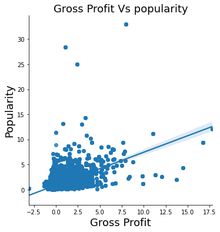

```python
plt.figure(figsize = (12,9));
sns.lmplot(x = 'gross_profit_adj' , y = 'popularity', data = genres_movies);
plt.xlabel('Gross Profit' , fontsize = 18);
plt.ylabel('Popularity', fontsize =18);
plt.title('Gross Profit Vs popularity',fontsize = 18);
```